# Cómo funcionan las métricas de la serie temporal de probabilidad de quema

Paso 03 del mapeo de fuego — explicación para el equipo

## Dónde encaja este paso

En el paso **03** del mapeo (`03-bp_ts_metrics.py`) hacemos, para cada **año × carta**:

1. Calculamos la **probabilidad de quema por observación** — aplicamos la regresión logística del paso 02 a *cada* imagen Landsat, píxel por píxel, fecha por fecha.
2. Cada píxel queda así con una **serie temporal intra-anual** de probabilidades en fechas irregulares (según cuándo hubo imágenes sin nubes).
3. Reducimos esa serie a un puñado de **métricas anuales** que resumen la señal de fuego, y exportamos una imagen de 16 bandas.

> Este notebook usa los **nombres de banda tal como salen en la imagen exportada** (16 bandas). Cada métrica del salto existe en **dos versiones** — K = 3 (robusta) y K = 2 (sensible) —; los gráficos de más abajo muestran ambas.

## Las variables exportadas, por concepto

Vista rápida de las 16 bandas agrupadas por qué miden (**sin el sufijo K**):

| Concepto | Variable | Qué significa |
| --- | --- | --- |
| **Magnitud** | `pmax` | Probabilidad de quema máxima sostenida en el año — cuán **alta** llega la señal |
| **Persistencia** | `minfore` | Piso de la probabilidad justo **después** del salto — que la señal alta se mantenga |
| **Cambio (el salto)** | `delta` | Tamaño del salto sostenido = piso posterior − techo previo; **indicador central de fuego** |
| **Temporalidad** | `jumpgap` | **Días** entre la última obs baja y la primera alta — nitidez de la transición |
|  | `prevwidth` / `postwidth` | Amplitud en días de la ventana previa / posterior — contexto de densidad de imágenes |
|  | `date_post` | Día del año de la obs posterior — **fecha candidata** de la quema |
| **Calidad** | `n` | Nº de observaciones válidas del año (centinelas −1 = no quemable, −2 = no observado) |

Cada variable del salto se exporta en **dos anchos de ventana** (sufijo `3` y `2`: `delta3_peak`/`delta2_peak`, `minfore3_peak`/`minfore2_peak`, …); `pmax` va en **tres** (`pmax1/2/3`) y `n` es **única**. El detalle formal está abajo.

## Las métricas del salto en detalle

Todo (salvo `pmax*` y `n`) se ancla en `t*`: la observación donde el **salto `delta` es máximo** en el año (el “momento del incendio”). Alrededor de `t*` se define una **ventana previa** y una **ventana posterior** de K observaciones cada una.

| Banda (K = 3 / K = 2) | Qué es | Definición K = 3 | Definición K = 2 |
| --- | --- | --- | --- |
| `minfore3_peak` / `minfore2_peak` | Piso posterior al salto — **persistencia** de la señal alta | `min(p[t*], p[t*+1], p[t*+2])` | `min(p[t*], p[t*+1])` |
| `maxback3` / `maxback2` *(no se exportan; = `minforeK_peak − deltaK_peak`)* | **Techo** previo — línea base antes del salto | `max(p[t*−3], p[t*−2], p[t*−1])` | `max(p[t*−2], p[t*−1])` |
| `delta3_peak` / `delta2_peak` | El **salto** sostenido | `minfore3_peak − maxback3` | `minfore2_peak − maxback2` |
| `jumpgap3` / `jumpgap2` | Días entre la última obs previa y la primera posterior. Corto ⇒ evidencia fuerte de fuego; largo ⇒ cambio lento o baja densidad | `d[t*] − d[t*−1]` | `d[t*] − d[t*−1]` |
| `prevwidth3` / `prevwidth2` | Amplitud (días) de la ventana previa | `d[t*−1] − d[t*−3]` | `d[t*−1] − d[t*−2]` |
| `postwidth3` / `postwidth2` | Amplitud (días) de la ventana posterior | `d[t*+2] − d[t*]` | `d[t*+1] − d[t*]` |
| `date_post3` / `date_post2` | DOY (1–366) de la obs posterior; `− jumpgap/2` ≈ fecha de quema | `d[t*] + 1` | `d[t*] + 1` |

`jumpgap*` y `date_post*` comparten fórmula entre familias, pero cada K usa **su propio `t*`** (el argmax de *su* `delta`), que puede caer en observaciones distintas. Aparte, sin anclarse a `t*`: `pmax1` = máx. probabilidad cruda del año, `pmax2`/`pmax3` = máx. de `minfore2`/`minfore3` (magnitud persistente), y `n` = cantidad de observaciones válidas.

La idea clave del `delta`: usamos el **mínimo** hacia adelante (la señal alta tiene que *sostenerse* en las K obs siguientes — un solo pico aislado no alcanza) menos el **máximo** hacia atrás (basta un valor alto previo para *anular* el salto — así una quema vieja no se vuelve a detectar). Es el salto más conservador posible: exige un escalón limpio.

## El gráfico

```r
library(tidyverse)

# Mismo tema que el resto de los notebooks del repo (única fuente de estilo).
theme_burn <- function(base_size = 16) {
  theme_minimal(base_size = base_size) +
    theme(
      strip.text.x     = element_text(face = "bold", size = base_size,
                                      margin = margin(b = 6)),
      panel.spacing    = unit(1.1, "lines"),
      panel.grid.minor = element_blank(),
      panel.grid.major.x = element_blank(),
      panel.grid.major.y = element_line(colour = "grey90", linewidth = 0.35),
      axis.line        = element_line(colour = "grey50", linewidth = 0.4),
      plot.title       = element_text(face = "bold", size = base_size + 2,
                                      margin = margin(b = 6)),
      plot.subtitle    = element_text(size = base_size - 3, colour = "grey45",
                                      margin = margin(b = 8)),
      legend.position  = "top"
    )
}
theme_set(theme_burn())
```

```r
# --- Serie sintética: muchos ceros -> salto -> muchos ~1, con un poco de ruido ---
set.seed(7)
n   <- 20
doy <- round(seq(15, 355, length.out = n))          # ~18 d de separación
base  <- c(rep(0, 10), rep(1, 10))                    # escalón limpio
noise <- rnorm(n, 0, 0.045)
p     <- pmin(pmax(base + noise, 0), 1)               # recorte a [0, 1]

# t* = primera obs posterior al salto. Ventana previa = t*-3..t*-1, posterior = t*..t*+2
tstar <- 11L
prev_idx <- c(8L, 9L, 10L)     # t*-3, t*-2, t*-1
post_idx <- c(11L, 12L, 13L)   # t*,   t*+1, t*+2

maxback3   <- max(p[prev_idx])                 # techo previo
minfore3   <- min(p[post_idx])                 # piso posterior
delta3     <- minfore3 - maxback3              # el salto
jumpgap3   <- doy[tstar] - doy[tstar - 1L]     # días entre t*-1 y t*
prevwidth3 <- doy[tstar - 1L] - doy[tstar - 3L]
postwidth3 <- doy[tstar + 2L] - doy[tstar]
date_post3 <- doy[tstar] + 1L

# Rol de cada observación (para colorear los puntos de las ventanas K=3).
role <- rep("otra", n)
role[prev_idx] <- "previa (K=3)"
role[post_idx] <- "posterior (K=3)"
role <- factor(role, levels = c("previa (K=3)", "posterior (K=3)", "otra"))

panel_levels <- c(
  "A · El salto:  delta3_peak, minfore3_peak, maxback3, jumpgap3",
  "B · Las ventanas temporales:  prevwidth3, postwidth3, date_post3"
)

# La misma serie se dibuja en los dos paneles.
df_prob <- tidyr::crossing(
  panel = factor(panel_levels, levels = panel_levels),
  tibble(doy = doy, p = p, role = role)
)
```

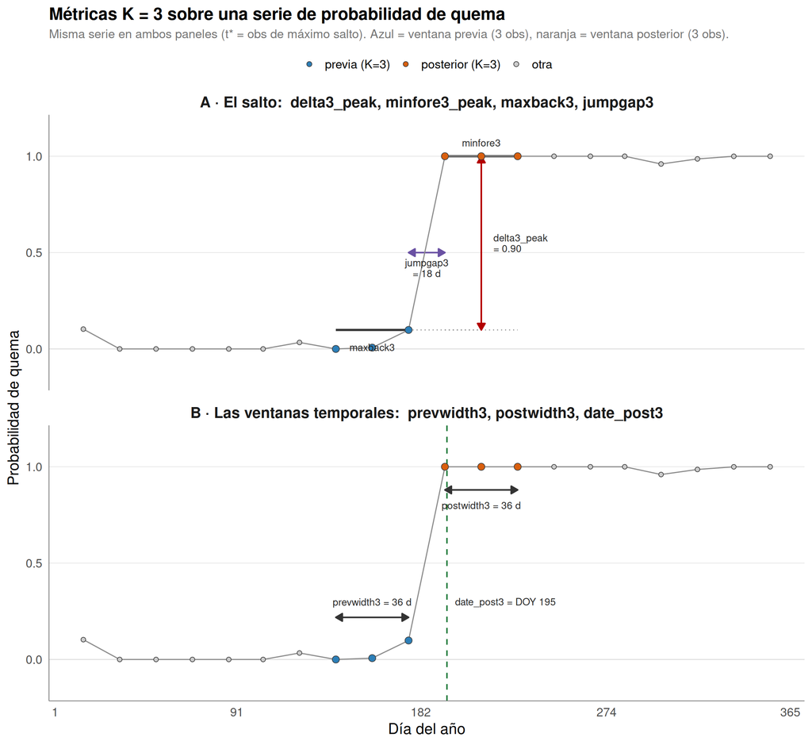

```r
pA <- panel_levels[1]
pB <- panel_levels[2]
col_prev <- "#2C7FB8"; col_post <- "#D95F0E"

arr <- arrow(length = unit(0.11, "inches"), ends = "both", type = "closed")

# ---- Panel A: segmentos de nivel, salto (delta) y jumpgap ----
segA <- tibble(
  panel = factor(c(pA, pA, pA), levels = panel_levels),
  x    = c(doy[prev_idx[1]], doy[post_idx[1]], doy[post_idx[1]]),
  xend = c(doy[prev_idx[3]], doy[post_idx[3]], doy[post_idx[3]]),
  y    = c(maxback3, minfore3, maxback3),   # 3ra fila = guía punteada de maxback3
  yend = c(maxback3, minfore3, maxback3),
  kind = c("nivel", "nivel", "guia")
)
# Flecha vertical del salto (delta3) un poco a la derecha de t*.
x_delta <- doy[post_idx[2]]
arrA_delta <- tibble(panel = factor(pA, levels = panel_levels),
                     x = x_delta, xend = x_delta, y = maxback3, yend = minfore3)
guiaA_delta <- tibble(panel = factor(pA, levels = panel_levels),   # base hasta la flecha
                      x = doy[prev_idx[3]], xend = x_delta,
                      y = maxback3, yend = maxback3)
# Flecha horizontal del jumpgap.
y_gap <- 0.5
arrA_gap <- tibble(panel = factor(pA, levels = panel_levels),
                   x = doy[tstar - 1L], xend = doy[tstar], y = y_gap, yend = y_gap)

txtA <- tibble(
  panel = factor(pA, levels = panel_levels),
  x = c(doy[prev_idx[2]], doy[post_idx[2]], x_delta + 6, (doy[tstar-1L]+doy[tstar])/2),
  y = c(maxback3 - 0.09, minfore3 + 0.07, (maxback3 + minfore3)/2, y_gap - 0.08),
  label = c("maxback3", "minfore3",
            sprintf("delta3_peak\n= %.2f", delta3),
            sprintf("jumpgap3\n= %d d", jumpgap3)),
  hjust = c(0.5, 0.5, 0, 0.5)
)

# ---- Panel B: anchos de ventana y date_post3 ----
arrB <- tibble(
  panel = factor(c(pB, pB), levels = panel_levels),
  x    = c(doy[prev_idx[1]], doy[post_idx[1]]),
  xend = c(doy[prev_idx[3]], doy[post_idx[3]]),
  y    = c(maxback3 + 0.12, minfore3 - 0.12),
  yend = c(maxback3 + 0.12, minfore3 - 0.12)
)
vlineB <- tibble(panel = factor(pB, levels = panel_levels), x = date_post3)
txtB <- tibble(
  panel = factor(c(pB, pB, pB), levels = panel_levels),
  x = c(doy[prev_idx[2]], doy[post_idx[2]], date_post3 + 4),
  y = c(maxback3 + 0.20, minfore3 - 0.20, 0.30),
  label = c(sprintf("prevwidth3 = %d d", prevwidth3),
            sprintf("postwidth3 = %d d", postwidth3),
            sprintf("date_post3 = DOY %d", date_post3)),
  hjust = c(0.5, 0.5, 0)
)

ggplot(df_prob, aes(doy, p)) +
  # nivel de referencia
  geom_hline(yintercept = 0, colour = "grey85", linewidth = 0.35) +
  # --- panel A ---
  geom_segment(data = segA %>% filter(kind == "guia"),
               aes(x = x, xend = xend, y = y, yend = yend),
               linetype = "dotted", colour = "grey55", linewidth = 0.5) +
  geom_segment(data = segA %>% filter(kind == "nivel"),
               aes(x = x, xend = xend, y = y, yend = yend),
               colour = "grey20", linewidth = 1.1) +
  geom_segment(data = guiaA_delta, aes(x = x, xend = xend, y = y, yend = yend),
               linetype = "dotted", colour = "grey55", linewidth = 0.5) +
  geom_segment(data = arrA_delta, aes(x = x, xend = xend, y = y, yend = yend),
               arrow = arr, colour = "#B30000", linewidth = 0.8) +
  geom_segment(data = arrA_gap, aes(x = x, xend = xend, y = y, yend = yend),
               arrow = arr, colour = "#6A51A3", linewidth = 0.8) +
  # --- panel B ---
  geom_vline(data = vlineB, aes(xintercept = x),
             linetype = "dashed", colour = "#1B7837", linewidth = 0.7) +
  geom_segment(data = arrB, aes(x = x, xend = xend, y = y, yend = yend),
               arrow = arr, colour = "grey20", linewidth = 0.8) +
  # --- serie (en ambos paneles) ---
  geom_line(colour = "grey55", linewidth = 0.55) +
  geom_point(aes(fill = role, size = role), shape = 21, colour = "grey25",
             stroke = 0.5) +
  # --- etiquetas ---
  geom_text(data = txtA, aes(x = x, y = y, label = label, hjust = hjust),
            size = 3.7, lineheight = 0.9, colour = "grey15") +
  geom_text(data = txtB, aes(x = x, y = y, label = label, hjust = hjust),
            size = 3.7, lineheight = 0.9, colour = "grey15") +
  facet_wrap(~ panel, ncol = 1) +
  scale_fill_manual(name = NULL,
                    values = c("previa (K=3)" = col_prev,
                               "posterior (K=3)" = col_post,
                               "otra" = "grey80")) +
  scale_size_manual(guide = "none",
                    values = c("previa (K=3)" = 3.2,
                               "posterior (K=3)" = 3.2, "otra" = 2.0)) +
  scale_x_continuous(breaks = c(1, 91, 182, 274, 365)) +
  scale_y_continuous(limits = c(-0.15, 1.15), breaks = c(0, 0.5, 1)) +
  labs(
    x = "Día del año",
    y = "Probabilidad de quema",
    title = "Métricas K = 3 sobre una serie de probabilidad de quema",
    subtitle = paste0(
      "Misma serie en ambos paneles (t* = obs de máximo salto). ",
      "Azul = ventana previa (3 obs), naranja = ventana posterior (3 obs)."
    )
  )
```

**Cómo leer el gráfico**

- **Panel A** — el salto. La línea negra sobre las 3 obs **previas** marca `maxback3` (su *máximo*); la línea negra sobre las 3 obs **posteriores** marca `minfore3_peak` (su *mínimo*). La flecha vertical roja es `delta3_peak` = `minfore3 − maxback3`, la magnitud del salto sostenido. La flecha horizontal violeta es `jumpgap3`, los días entre la última obs previa y la primera posterior (corto ⇒ transición nítida, evidencia fuerte de fuego).
- **Panel B** — el tiempo que abarcan las ventanas. `prevwidth3` y `postwidth3` son la amplitud en días de cada ventana de 3 obs (bajo baja densidad de imágenes se ensanchan). La línea verde punteada es `date_post3`, el día del año de la obs posterior — el ancla para estimar la **fecha de quema** (`date_post3 − jumpgap3/2`).

## La familia gemela K = 2

La familia K = 2 es **idéntica en construcción, pero con ventanas de solo 2 observaciones** (ver la tabla detallada arriba). Con ventanas más angostas es **más permisiva y sensible** (necesita menos obs consecutivas para confirmar el salto), útil bajo **baja densidad de imágenes**; K = 3 es **más robusta** (exige que la señal alta se sostenga en 3 obs, no en 2). Cada `deltaK` busca su **propio `t*`** de forma independiente; sobre un escalón limpio como este ambos coinciden, pero en series ruidosas el óptimo puede diferir por ventana.

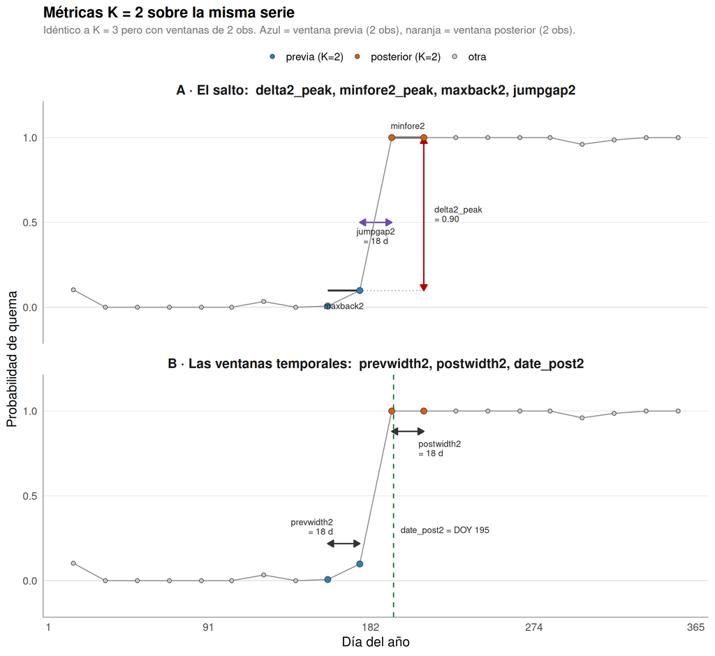

```r
# Misma serie, mismo t*. Ventanas K=2: previa = t*-2..t*-1, posterior = t*..t*+1
prev_idx2 <- c(9L, 10L)     # t*-2, t*-1
post_idx2 <- c(11L, 12L)    # t*,   t*+1

maxback2   <- max(p[prev_idx2])
minfore2   <- min(p[post_idx2])
delta2     <- minfore2 - maxback2
jumpgap2   <- doy[tstar] - doy[tstar - 1L]
prevwidth2 <- doy[tstar - 1L] - doy[tstar - 2L]
postwidth2 <- doy[tstar + 1L] - doy[tstar]
date_post2 <- doy[tstar] + 1L

role2 <- rep("otra", n)
role2[prev_idx2] <- "previa (K=2)"
role2[post_idx2] <- "posterior (K=2)"
role2 <- factor(role2, levels = c("previa (K=2)", "posterior (K=2)", "otra"))

panel2_levels <- c(
  "A · El salto:  delta2_peak, minfore2_peak, maxback2, jumpgap2",
  "B · Las ventanas temporales:  prevwidth2, postwidth2, date_post2"
)
df_prob2 <- tidyr::crossing(
  panel = factor(panel2_levels, levels = panel2_levels),
  tibble(doy = doy, p = p, role = role2)
)

p2A <- panel2_levels[1]; p2B <- panel2_levels[2]

# ---- Panel A ----
segA2 <- tibble(
  panel = factor(c(p2A, p2A), levels = panel2_levels),
  x    = c(doy[prev_idx2[1]], doy[post_idx2[1]]),
  xend = c(doy[prev_idx2[2]], doy[post_idx2[2]]),
  y    = c(maxback2, minfore2), yend = c(maxback2, minfore2)
)
x_delta2 <- doy[post_idx2[2]]
arrA2_delta <- tibble(panel = factor(p2A, levels = panel2_levels),
                      x = x_delta2, xend = x_delta2, y = maxback2, yend = minfore2)
guiaA2_delta <- tibble(panel = factor(p2A, levels = panel2_levels),
                       x = doy[prev_idx2[2]], xend = x_delta2,
                       y = maxback2, yend = maxback2)
arrA2_gap <- tibble(panel = factor(p2A, levels = panel2_levels),
                    x = doy[tstar - 1L], xend = doy[tstar], y = 0.5, yend = 0.5)
txtA2 <- tibble(
  panel = factor(p2A, levels = panel2_levels),
  x = c(mean(doy[prev_idx2]), mean(doy[post_idx2]), x_delta2 + 6,
        (doy[tstar-1L]+doy[tstar])/2),
  y = c(maxback2 - 0.09, minfore2 + 0.07, (maxback2 + minfore2)/2, 0.42),
  label = c("maxback2", "minfore2",
            sprintf("delta2_peak\n= %.2f", delta2),
            sprintf("jumpgap2\n= %d d", jumpgap2)),
  hjust = c(0.5, 0.5, 0, 0.5)
)

# ---- Panel B ----
arrB2 <- tibble(
  panel = factor(c(p2B, p2B), levels = panel2_levels),
  x    = c(doy[prev_idx2[1]], doy[post_idx2[1]]),
  xend = c(doy[prev_idx2[2]], doy[post_idx2[2]]),
  y    = c(maxback2 + 0.12, minfore2 - 0.12),
  yend = c(maxback2 + 0.12, minfore2 - 0.12)
)
vlineB2 <- tibble(panel = factor(p2B, levels = panel2_levels), x = date_post2)
txtB2 <- tibble(
  panel = factor(c(p2B, p2B, p2B), levels = panel2_levels),
  x = c(mean(doy[prev_idx2]) - 6, mean(doy[post_idx2]) + 6, date_post2 + 4),
  y = c(maxback2 + 0.22, minfore2 - 0.22, 0.30),
  label = c(sprintf("prevwidth2\n= %d d", prevwidth2),
            sprintf("postwidth2\n= %d d", postwidth2),
            sprintf("date_post2 = DOY %d", date_post2)),
  hjust = c(1, 0, 0)
)

ggplot(df_prob2, aes(doy, p)) +
  geom_hline(yintercept = 0, colour = "grey85", linewidth = 0.35) +
  geom_segment(data = guiaA2_delta, aes(x = x, xend = xend, y = y, yend = yend),
               linetype = "dotted", colour = "grey55", linewidth = 0.5) +
  geom_segment(data = segA2, aes(x = x, xend = xend, y = y, yend = yend),
               colour = "grey20", linewidth = 1.1) +
  geom_segment(data = arrA2_delta, aes(x = x, xend = xend, y = y, yend = yend),
               arrow = arr, colour = "#B30000", linewidth = 0.8) +
  geom_segment(data = arrA2_gap, aes(x = x, xend = xend, y = y, yend = yend),
               arrow = arr, colour = "#6A51A3", linewidth = 0.8) +
  geom_vline(data = vlineB2, aes(xintercept = x),
             linetype = "dashed", colour = "#1B7837", linewidth = 0.7) +
  geom_segment(data = arrB2, aes(x = x, xend = xend, y = y, yend = yend),
               arrow = arr, colour = "grey20", linewidth = 0.8) +
  geom_line(colour = "grey55", linewidth = 0.55) +
  geom_point(aes(fill = role, size = role), shape = 21, colour = "grey25",
             stroke = 0.5) +
  geom_text(data = txtA2, aes(x = x, y = y, label = label, hjust = hjust),
            size = 3.7, lineheight = 0.9, colour = "grey15") +
  geom_text(data = txtB2, aes(x = x, y = y, label = label, hjust = hjust),
            size = 3.7, lineheight = 0.9, colour = "grey15") +
  facet_wrap(~ panel, ncol = 1) +
  scale_fill_manual(name = NULL,
                    values = c("previa (K=2)" = col_prev,
                               "posterior (K=2)" = col_post,
                               "otra" = "grey80")) +
  scale_size_manual(guide = "none",
                    values = c("previa (K=2)" = 3.2,
                               "posterior (K=2)" = 3.2, "otra" = 2.0)) +
  scale_x_continuous(breaks = c(1, 91, 182, 274, 365)) +
  scale_y_continuous(limits = c(-0.15, 1.15), breaks = c(0, 0.5, 1)) +
  labs(
    x = "Día del año",
    y = "Probabilidad de quema",
    title = "Métricas K = 2 sobre la misma serie",
    subtitle = paste0(
      "Idéntico a K = 3 pero con ventanas de 2 obs. ",
      "Azul = ventana previa (2 obs), naranja = ventana posterior (2 obs)."
    )
  )
```

Los valores numéricos de los gráficos (`delta3_peak`/`delta2_peak`, `jumpgap*`, `prevwidth*`, `postwidth*`, `date_post*`) son exactamente lo que queda guardado en cada píxel de la imagen exportada; los umbrales para decidir qué es fuego se aplican **después**, en función de la densidad de observaciones (banda `n`) y de los pasos de segmentación y enmascarado.